# Lab 5

[Link to my Github Repository](https://github.com/bigturtle13/GSB544/tree/main/Week%206)

Note: P#:Q# (ex: P1:Q3 means Problem 1, Question 3. I used this to organize my code.)

Import Packages

```python
import pandas as pd
import numpy as np
from plotnine import *
from sklearn.linear_model import *
from sklearn.model_selection import *
from sklearn.preprocessing import OneHotEncoder
from sklearn.metrics import *
```

Part One: Data Exploration

P1:Q1 Read in the dataset, and display some summaries of the data.(Note: this is not a print of full dataset, just first 15 values)

```python
#read in the dataset
df = pd.read_csv("/Users/amritdhillon/Desktop/GSB544/Week 6/insurance_costs_1.csv")

print(df.head(15)) #First 15 entries of data(NOT THE FULL DATASET JUST A HEAD(20) :D

df.describe() #Summary statistics for data
```

```
    age     sex     bmi smoker     region      charges
0    19  female  27.900    yes  southwest  16884.92400
1    33    male  22.705     no  northwest  21984.47061
2    32    male  28.880     no  northwest   3866.85520
3    31  female  25.740     no  southeast   3756.62160
4    60  female  25.840     no  northwest  28923.13692
5    25    male  26.220     no  northeast   2721.32080
6    62  female  26.290    yes  southeast  27808.72510
7    56  female  39.820     no  southeast  11090.71780
8    27    male  42.130    yes  southeast  39611.75770
9    23    male  23.845     no  northeast   2395.17155
10   30    male  35.300    yes  southwest  36837.46700
11   60  female  36.005     no  northeast  13228.84695
12   22    male  35.600    yes  southwest  35585.57600
13   18  female  26.315     no  northeast   2198.18985
14   26    male  20.800     no  southwest   2302.30000
```

|  | age | bmi | charges |
| --- | --- | --- | --- |
| count | 431.000000 | 431.000000 | 431.000000 |
| mean | 37.960557 | 30.768898 | 12297.098118 |
| std | 16.363909 | 6.111362 | 11876.527128 |
| min | 18.000000 | 15.960000 | 1131.506600 |
| 25% | 22.000000 | 26.357500 | 2710.444575 |
| 50% | 34.000000 | 30.590000 | 9866.304850 |
| 75% | 55.000000 | 35.272500 | 14510.872600 |
| max | 64.000000 | 49.060000 | 55135.402090 |

P1:Q2 Fix any concerns you have about the data.

```python
#fix any concerns with dataset
na = df.isna().sum()
#print(na)
#no na values no need to omit or impute any values

#converts all categorical variables to dummy/indicator variables
df1 = pd.get_dummies(df) * 1
```

P1:Q3 Make up to three plots comparing the response variable (charges) to one of the predictor variables. briefly discuss each plot

BMI vs. Charges Scatterplot

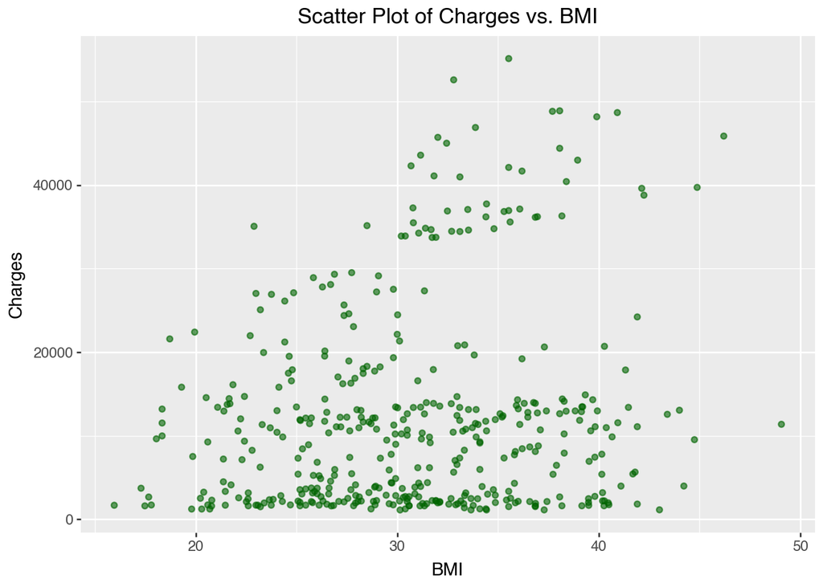

```python
(
    ggplot(df1, aes(x='bmi', y='charges'))
    + geom_point(alpha=0.6,color = "darkgreen")
    +labs(
        title='Scatter Plot of Charges vs. BMI',
        x='BMI',
        y='Charges'
    )
)
```

This plot shows the spread of charges data points as the BMI of a subject in the dataset increases. While the majority of points are spread across the bottom of the y-axis meaning there were low medical costs billed by health insurance, the points that begin to slide towards the top are closer to the right side of the y axis. It seems that to some small degree as BMI increases, medical costs billed by health insurance also seem to increase a bit.

Average Charges by Region Bar Chart

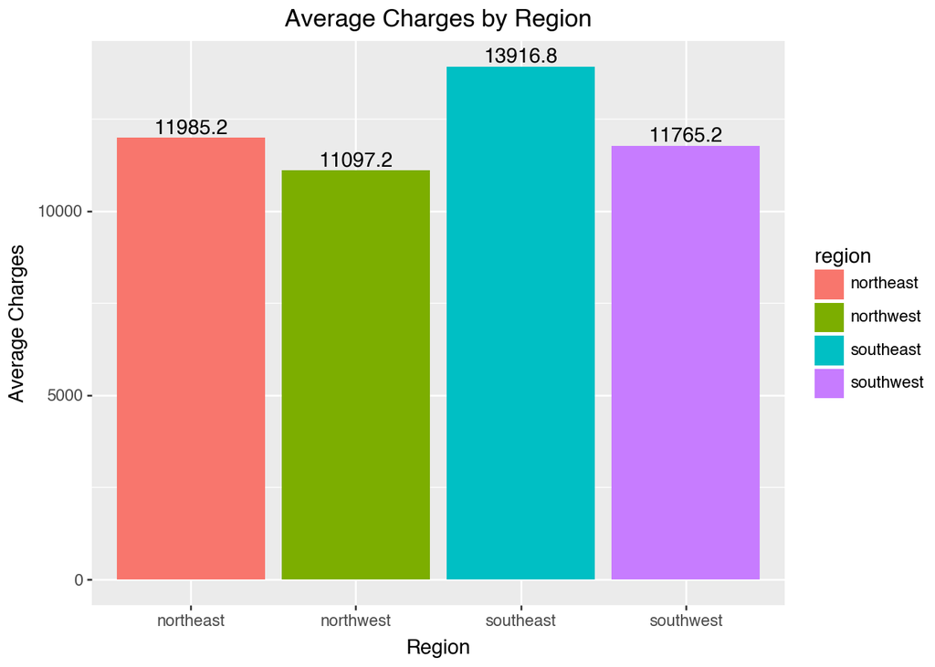

```python
avg_chg_by_region = df.groupby('region', as_index=False)['charges'].mean()
#making sure averages are correct for bars
#test = df[df['region'] == 'northeast']
#t2 = test['charges'].mean();t2

(
    ggplot(avg_chg_by_region, aes(x='region', y='charges',fill = 'region'))
    + geom_bar(stat='identity')
    + geom_text(aes(label=round(avg_chg_by_region['charges'], 1)), va = 'bottom')
    # add label to top of barss
    + labs(title='Average Charges by Region', x='Region', y='Average Charges')
)
```

This bar chart groups each of the four unique regions in the dataset and finds their average individual medical costs billed by health insurance. The bars make it evident that charges in the southeast are the highest by far with an average of $13,916.8, while the northwest region holds the lowest average of $11,097.20. It would be interesting to then find the average BMI and average age of these regions to see if they have any effect on the higher or lower medical costs.

Charges vs. Age Scatterplot with Regression Trend Line

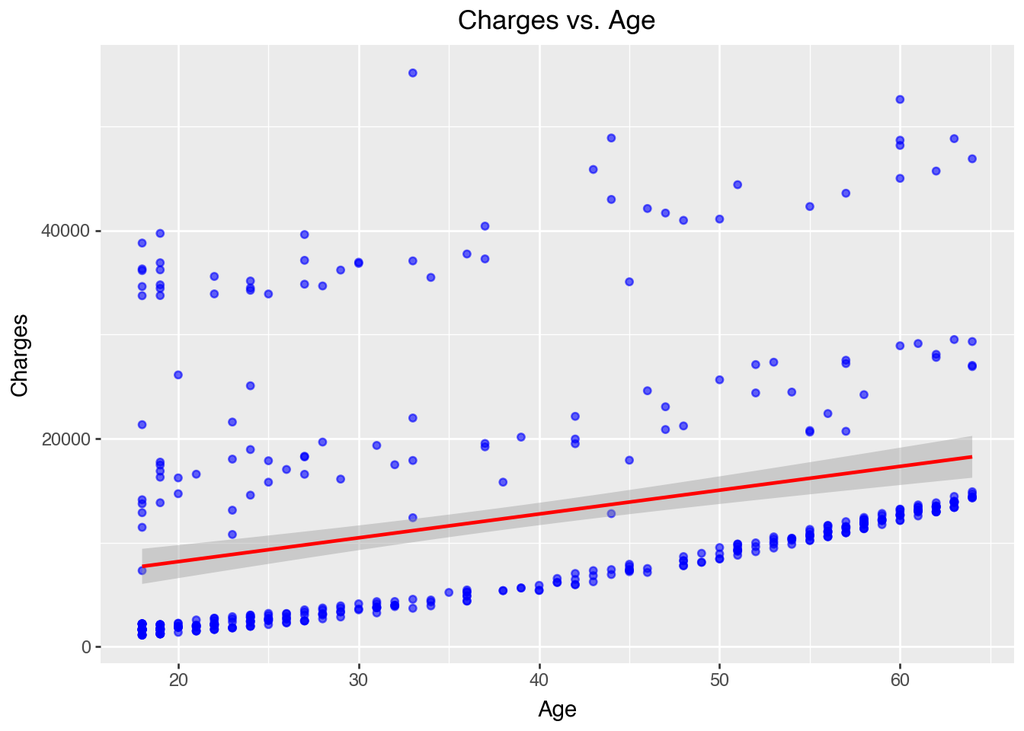

```python
(
    ggplot(df1.sort_values('age'), aes(x='age', y='charges'))
    + geom_point(color='blue', alpha=0.6)
    + geom_smooth(method='lm', color='red') # linear regression trend line
    + labs(
        title='Charges vs. Age',
        x='Age',
        y='Charges'
    )
)
```

This plot shows a scatter plot of all data points as age increases. The scatterplot points and the regression line indicate that as the age of a subject increases, the individual costs billed by health insurance also begin to increase. On another note, the data also seems to suggest that extremely high medical costs are common across all ages, but they are not as common as the data points seemingly setting the trend for charges.

Part Two: Simple Linear Models

P2:Q1 Construct a simple linear model to predict the insurance charges from the beneficiary’s age. Discuss the model fit, and interpret the coefficient estimates.

```python
x = df1[['age']]
y = df1['charges']

model = LinearRegression()
model.fit(x,y)

y_pred = model.predict(x)

#looked up how to get these values
print(f"Intercept (β0): {model.intercept_:.2f}")
print(f"Coefficient (β1 for age): {model.coef_[0]:.2f}")

r2 = r2_score(y, y_pred)
mse = mean_squared_error(y, y_pred)
#rmse = np.sqrt(mse), chose to use R squared and MSE, don't need
#mad = mean_absolute_error(y, y_pred), chose to use R squared and MSE, don't need
print(f"R-squared: {r2:.3f}")
print(f"MSE: {mse:.2f}")
#print(f"RMSE: {rmse:.2f}"), chose to use R squared and MSE, don't need
#print(f"MAD: {mad:.2f}"), chose to use R squared and MSE, don't need
```

```
Intercept (β0): 3611.76
Coefficient (β1 for age): 228.80
R-squared: 0.099
MSE: 126739267.91
```

Model 1 which uses only age as a predictor, is a poor fit using R squared and MSE as evaluators. The R squared is below 0.1 which is extremely low and means that age alone can only explain about 9.9% of the variation in charges. Additionally, the MSE value of 126739267.91 is extremely high and indicates there are large errors in the predictions. With an intercept coefficient of $3611.76, this means this is the baseline average cost of a charge. Every additional unit in age is associate with a $228.80 increase in charges.

P2:Q2 Make a model that also incorporates the variable sex. Report your results.

```python
x = df1[['age', 'sex_female']]
y = df1['charges']

model = LinearRegression()
model.fit(x,y)

y_pred = model.predict(x)

#looked up how to get these values
print(f"Intercept (β0): {model.intercept_:.2f}")
print(f"Coefficient (β1 for age): {model.coef_[0]:.2f}")
print(f"Coefficient (β2 for sex_female): {model.coef_[1]:.2f}")

r2 = r2_score(y, y_pred)
mse = mean_squared_error(y, y_pred)
print(f"R-squared: {r2:.3f}")
print(f"MSE: {mse:.2f}")
```

```
Intercept (β0): 3965.16
Coefficient (β1 for age): 228.43
Coefficient (β2 for sex_female): -649.83
R-squared: 0.100
MSE: 126633939.68
```

Model 2 which uses both age as well as sex as predictors is not much better of a fit than model 1. Model 2 has a R squared value of 0.1, meaning that the model can only explain for about 10% of variation in charges. Like Model 1 it also has an extremely high MSE value(126633939.68), indicating predictions are very far off actual values. The intercept of the model means that the baseline cost of a charge in Model 2 is about $3965.16. The coefficient value B1 representing age, means that there is an approximate $228.43 increase in charges for each unit increase in wage. Holding age constant, the coefficient value B2 represents the change in charges estimated based on whether the subject is female. For female subjects, charges are approximately -$649.83 lower males.

P2:Q3 Now make a model that does not include sex, but does include smoker. Report your results.

```python
x = df1[['age', 'smoker_no']]
y = df1['charges']

model = LinearRegression()
model.fit(x,y)

y_pred = model.predict(x)

#looked up how to get these values
print(f"Intercept (β0): {model.intercept_:.2f}")
print(f"Coefficient (β1 for age): {model.coef_[0]:.2f}")
print(f"Coefficient (β2 for smoker_no): {model.coef_[1]:.2f}")

r2 = r2_score(y, y_pred)
mse = mean_squared_error(y, y_pred)
print(f"R-squared: {r2:.3f}")
print(f"MSE: {mse:.2f}")
```

```
Intercept (β0): 21882.02
Coefficient (β1 for age): 253.15
Coefficient (β2 for smoker_no): -24048.87
R-squared: 0.760
MSE: 33719831.47
```

P2:Q4 Which model (Q2 or Q3) do you think better fits the data? Justify your answer by calculating the MSE for each model, and also by comparing R-squared values

```python
x = df1.drop('charges', axis=1) #keeps all columns but the response
y = df1['charges']

x_train, x_test, y_train, y_test = train_test_split(x, y, test_size=0.25, random_state=1031)

models = {
    "Model 1": ['age'],
    #Construct a simple linear model to predict the insurance charges from the beneficiary’s age.
    "Model 2": ['age', 'sex_female',], #used sex_male as reference, avoid multicollinearity
    #Make a model that also incorporates the variable sex.
    "Model 3": ['age', 'smoker_no'], #used smoker_yes as reference, avoid milticollinearity
    #Now make a model that does not include sex, but does include smoker.
}

rows = []
for name, Xcols in models.items():
    X = x_train[Xcols]
    model = LinearRegression().fit(X, y_train)
    y_test_ = model.predict(x_test[Xcols])
    x_test[f"{name}_predict"] = y_test_
    test_rmse = np.sqrt(mean_squared_error(y_test, y_test_))
    test_r2 = r2_score(y_test, y_test_)
    y_test_ = x_test[f"{name}_predict"]
    mse = mean_squared_error(y_test, y_test_)
    mad = mean_absolute_error(y_test, y_test_)
    rows.append({"Model": name,"Intercept": model.intercept_,"Test RMSE": test_rmse, "Test R2": test_r2, "Test MSE": mse, "Test MAD": mad})
test_error = pd.DataFrame(rows)

#Which model (Q2 or Q3) do you think better fits the data? Justify your answer by #calculating the MSE for each model, and also by comparing R-squared values
test_error
```

|  | Model | Intercept | Test RMSE | Test R2 | Test MSE | Test MAD |
| --- | --- | --- | --- | --- | --- | --- |
| 0 | Model 1 | 3018.315156 | 12163.137268 | 0.055674 | 1.479419e+08 | 9167.939388 |
| 1 | Model 2 | 3682.907966 | 12197.834922 | 0.050279 | 1.487872e+08 | 9174.160670 |
| 2 | Model 3 | 21432.581073 | 6471.855097 | 0.732645 | 4.188491e+07 | 4048.027195 |

After comparing the MSE for each of my values I believe that Model 3 is the best fit for the data as it has the lowest MSE value as well as the highest R squared value in comparison to Models 1 and 2. The MSE of Model 3 was only 4.19 x 10^7, while Model 1 and 2 both had MSEs of a bout 1.48 x 10^8, considerably more. Furthermore, Model 3’s high R squared value indicated that it could explain for about 73% of the variation in charges, whereas the other two models could explain less than 6%. Considering all other metrics, Model 3 also has the most desirable values, so therefore, Model 3 is the best fit for this data.

Part Three: Multiple Linear Models

P3:Q1 Fit a model that uses age and bmi as predictors. (Do not include an interaction term, age*bmi, between these two.) Report your results. How does the MSE compare to the model in Part Two Q1? How does the R-squared compare?

```python
x = df1[['age', 'bmi']]
y = df1['charges']

model1 = LinearRegression()
model1.fit(x,y)

y_pred = model1.predict(x)

r2 = r2_score(y, y_pred)
mse = mean_squared_error(y, y_pred)
print(f"R-squared: {r2:.3f}")
print(f"MSE: {mse:.2f}")

print(f"Intercept (β0): {model1.intercept_:.2f}")
print(f"Coefficient (β1 for age): {model1.coef_[0]:.2f}")
print(f"Coefficient (β2 for bmi): {model1.coef_[1]:.2f}")
```

```
R-squared: 0.120
MSE: 123792439.58
Intercept (β0): -4627.53
Coefficient (β1 for age): 216.30
Coefficient (β2 for bmi): 283.20
```

This model is a poor fit for the data. With an R squared value of 0.12, this model can only explain about 12% of the variation in the response variable, charges. It also has an extrememly high MSE value meaning it’s predictions are likely off by a large amount. Having an intercept of -4627.53 means the baseline cost for a subject in this model is -$4627.53. Holding other predictors constant, a one unit increase in age results in about a $216.30 increase in charges, while a one unit increase in bmi results in about a $283.20 increase in charges. Comparing this to Part 2 Q1, this model is stronger, but that doesn’t mean its a good fit. The reason I can say this model is stronger is because it’s MSE value is smaller(123792439.58 < 126739267.91) meaning predictions are off by less, and it’s R squared value is higher meaning slightly more variation in charges can be explained by the model(0.12 > 0.099).

P3:Q2 Perhaps the relationships are not linear. Fit a model that uses age and age^2 as predictors. How do the MSE and R-squared compare to the model in P2 Q1?

```python
df1['ageS'] = df1['age']**2
x = df1[['age', 'ageS']]
y = df1['charges']

model2 = LinearRegression()
model2.fit(x,y)

y_pred = model2.predict(x)

r2 = r2_score(y, y_pred)
mse = mean_squared_error(y, y_pred)
print(f"R-squared: {r2:.3f}")
print(f"MSE: {mse:.2f}")
```

```
R-squared: 0.100
MSE: 126710293.81
```

Compared to the model in P2 Q1, this model is barely better. Not only does it have a slightly higher R squared(0.10 > 0.099) than the previous model, but it also has a lower MSE meaning that predicted values are off by less(126739267.91 > 126710293.81). The nonlinear term age^2 helps to strengthen the fit and capture curvature that is present in the model.

P3:Q3 Fit a polynomial model of degree 4. How do the MSE and R-squared compare to the model in P2 Q1?

```python
df1['ageS'] = df1['age']**2
df1['ageS3'] = df1['age']**3
df1['ageS4'] = df1['age']**4
x = df1[['age', 'ageS', 'ageS3', 'ageS4']]
y = df1['charges']

model3 = LinearRegression()
model3.fit(x,y)

y_pred = model3.predict(x)

r2 = r2_score(y, y_pred)
mse = mean_squared_error(y, y_pred)
print(f"R-squared: {r2:.3f}")
print(f"MSE: {mse:.2f}")
```

```
R-squared: 0.108
MSE: 125550389.65
```

Comparing this model again to P2 Q1, this model is better, and it improves slightly more than the previous model that used only age and age squared did. Compared to P2 Q1, it has a lower MSE(125550389.65 < 126739267.91) as well as a higher R squared value(0.108 > 0.099).

P3:Q4

```python
df1['ageS'] = df1['age']**2
df1['ageS3'] = df1['age']**3
df1['ageS4'] = df1['age']**4
df1['ageS5'] = df1['age']**5
df1['ageS6'] = df1['age']**6
df1['ageS7'] = df1['age']**7
df1['ageS8'] = df1['age']**8
df1['ageS9'] = df1['age']**9
df1['ageS10'] = df1['age']**10
df1['ageS11'] = df1['age']**11
df1['ageS12'] = df1['age']**12
x = df1[['age', 'ageS', 'ageS3', 'ageS4', 'ageS5', 'ageS6', 'ageS7', 'ageS8', 'ageS9', 'ageS10','ageS11', 'ageS12']]
y = df1['charges']

model4 = LinearRegression()
model4.fit(x,y)

y_pred = model4.predict(x)

r2 = r2_score(y, y_pred)
mse = mean_squared_error(y, y_pred)
print(f"R-squared: {r2:.3f}")
print(f"MSE: {mse:.2f}")
```

```
R-squared: 0.109
MSE: 125373053.69
```

Comparing this model again to P2 Q1, this model is better, and it improves slightly more than the previous model that used only age and age squared did. Compared to P2 Q1, it has a lower MSE(125373053.69 < 126739267.91) as well as a higher R squared value(0.109 > 0.099).

P3:Q6 Plot the predictions from your model in Q4 as a line plot on top of the scatterplot of your original data.

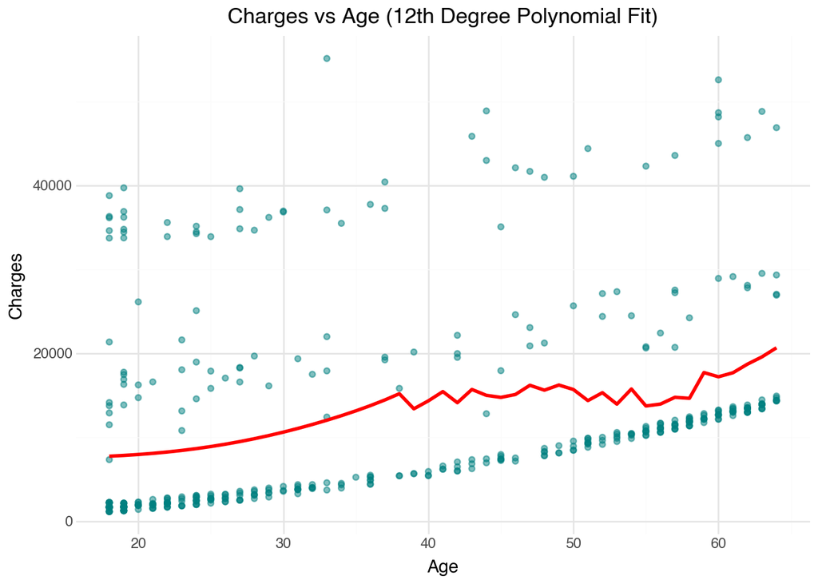

```python
y_pred = model4.predict(x) #using newest model, i already have this, easier to read though

#copies df1 and adds predictions as a column
m4 = df1.copy()
m4['ypred'] = y_pred

#sorts by age,
(
    ggplot(m4.sort_values('age'), aes(x='age', y='charges'))
    + geom_point(alpha=0.5, color='teal') #i like teal stands out well
    + geom_line(aes(y='ypred'), color='red', size=1.2)
    + labs(
        title='Charges vs Age (12th Degree Polynomial Fit)',
        x='Age',
        y='Charges'
    )
    #+ theme_classic() doesnt look good
    + theme_minimal() #looks way better
)
```

Part Four: New data

P4:Q1

Model with age

```python
train = pd.read_csv("/Users/amritdhillon/Desktop/GSB544/Week 6/insurance_costs_1.csv")
test = pd.read_csv("/Users/amritdhillon/Desktop/GSB544/Week 6/insurance_costs_2.csv")
#na
#na = df.isna().sum()
train = pd.get_dummies(train) * 1
test = pd.get_dummies(train) * 1

#fit model only on original data(training data)
xtrain = train[['age']]
ytrain = train['charges']

#fit linear model to training data
m5 = LinearRegression()
m5.fit(xtrain, ytrain)

#use training data to predict charges from test data
X_new = test[['age']]
y_pred_new = m5.predict(X_new)

#get MSE from new data
mse_new_1 = mean_squared_error(test['charges'], y_pred_new)
print(f"Model MSE: {mse_new_1:.2f}")
```

```
Model MSE: 126739267.91
```

Model with age and bmi and predictors

```python
train = pd.read_csv("/Users/amritdhillon/Desktop/GSB544/Week 6/insurance_costs_1.csv")
test = pd.read_csv("/Users/amritdhillon/Desktop/GSB544/Week 6/insurance_costs_2.csv")
#na
#na = df.isna().sum()
train = pd.get_dummies(train) * 1
test = pd.get_dummies(train) * 1

#fit model only on original data(training data)
xtrain = train[['age', 'bmi']]
ytrain = train['charges']

#fit linear model to training data
m6 = LinearRegression()
m6.fit(xtrain, ytrain)

#use training data to predict charges from test data
X_new = test[['age', 'bmi']]
y_pred_new = m6.predict(X_new)

#get MSE from new data
mse_new_2 = mean_squared_error(test['charges'], y_pred_new)
print(f"Model MSE: {mse_new_2:.2f}")
```

```
Model MSE: 123792439.58
```

Model with age, bmi, smoker as predictors

```python
train = pd.read_csv("/Users/amritdhillon/Desktop/GSB544/Week 6/insurance_costs_1.csv")
test = pd.read_csv("/Users/amritdhillon/Desktop/GSB544/Week 6/insurance_costs_2.csv")
#na
#na = df.isna().sum()
train = pd.get_dummies(train) * 1
test = pd.get_dummies(train) * 1

#fit model only on original data(training data)
xtrain = train[['age', 'bmi', 'smoker_no']]
ytrain = train['charges']

#fit linear model to training data
m7 = LinearRegression()
m7.fit(xtrain, ytrain)

#use training data to predict charges from test data
X_new = test[['age', 'bmi', 'smoker_no']]
y_pred_new = m7.predict(X_new)

#get MSE from new data
mse_new_3 = mean_squared_error(test['charges'], y_pred_new)
print(f"Model MSE: {mse_new_3:.2f}")
```

```
Model MSE: 30812111.94
```

Model with age, bmi, and interactive term with smoker as predictors [~ (age + bmi):smoker]

```python
train = pd.read_csv("/Users/amritdhillon/Desktop/GSB544/Week 6/insurance_costs_1.csv")
test = pd.read_csv("/Users/amritdhillon/Desktop/GSB544/Week 6/insurance_costs_2.csv")
#na
#na = df.isna().sum()
train = pd.get_dummies(train) * 1
test = pd.get_dummies(test) * 1

#new interaction term
train['age_smoker'] = train['age'] * train['smoker_yes']
train['bmi_smoker'] = train['bmi'] * train['smoker_yes']

test['age_smoker'] = test['age'] * test['smoker_yes']
test['bmi_smoker'] = test['bmi'] * test['smoker_yes']

#fit model only on original data(training data)
xtrain = train[['age_smoker', 'bmi_smoker']]
ytrain = train['charges']

#fit linear model to training data
m8 = LinearRegression()
m8.fit(xtrain, ytrain)

#use training data to predict charges from test data
X_new = test[['age_smoker', 'bmi_smoker']]
y_pred_new = m8.predict(X_new)

#get MSE from new data
mse_new_4 = mean_squared_error(test['charges'], y_pred_new)
print(f"Model MSE: {mse_new_4:.2f}")
```

```
Model MSE: 47626025.36
```

```python
train = pd.read_csv("/Users/amritdhillon/Desktop/GSB544/Week 6/insurance_costs_1.csv")
test = pd.read_csv("/Users/amritdhillon/Desktop/GSB544/Week 6/insurance_costs_2.csv")
#na
#na = df.isna().sum()
train = pd.get_dummies(train) * 1
test = pd.get_dummies(test) * 1

#new interaction term
train['age_smoker'] = train['age'] * train['smoker_yes']
train['bmi_smoker'] = train['bmi'] * train['smoker_yes']

test['age_smoker'] = test['age'] * test['smoker_yes']
test['bmi_smoker'] = test['bmi'] * test['smoker_yes']

#fit model only on original data(training data)
xtrain = train[['age', 'bmi', 'smoker_yes', 'age_smoker', 'bmi_smoker']]
ytrain = train['charges']

#fit linear model to training data
m9 = LinearRegression()
m9.fit(xtrain, ytrain)

#use training data to predict charges from test data
X_new = test[['age', 'bmi', 'smoker_yes', 'age_smoker', 'bmi_smoker']]
y_pred_new5 = m9.predict(X_new)

#get MSE from new data
mse_new_5 = mean_squared_error(test['charges'], y_pred_new5)
print(f"Model MSE: {mse_new_5:.2f}")
```

```
Model MSE: 21786256.87
```

P4:Q2 Report the MSE for each model’s new predictions. Based on this, which is the best model to use?

```python
mse_table = pd.DataFrame({ #manually create columns to display MSE values for each model
    "Model": [
        "Model 1: age",
        "Model 2: age + bmi",
        "Model 3: age + bmi + smoker",
        "Model 4: (age + bmi):smoker",
        "Model 5: (age + bmi)*smoker"
    ],
    "MSE": [mse_new_1, mse_new_2, mse_new_3, mse_new_4, mse_new_5]
}).sort_values("MSE", ascending=True)

print(mse_table)
```

```
                         Model           MSE
4  Model 5: (age + bmi)*smoker  2.178626e+07
2  Model 3: age + bmi + smoker  3.081211e+07
3  Model 4: (age + bmi):smoker  4.762603e+07
1           Model 2: age + bmi  1.237924e+08
0                 Model 1: age  1.267393e+08
```

Based upon the five models that we tested and the MSE values calculated, the best model that can be used is the last model which uses age, bmi, and smoker as predictors, with both quantitative variables having an interaction term with smoker (i.e. the formula ~ (age + bmi)*smoker).

P4:Q3 Make a plot showing the residuals of your final chosen model.

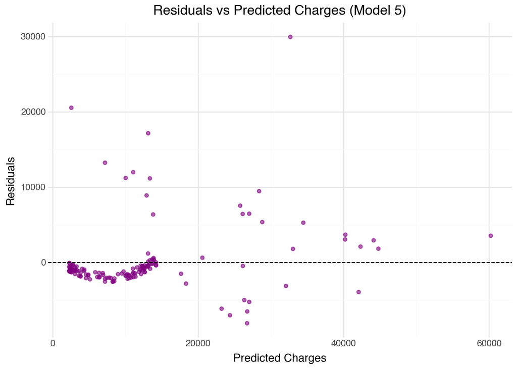

```python
#adding predictions and residuals to test, calculating residuals
test['predicted_charges'] = y_pred_new5 # predictions from Model 5
test['residuals'] = test['charges'] - test['predicted_charges']

#residual plot
(
    ggplot(test, aes(x='predicted_charges', y='residuals'))
    + geom_point(alpha=0.6, color='purple')
    + geom_hline(yintercept=0, color='black', linetype='dashed') #adds line at 0 to show shift from positive to negative values easier
    + labs(
        title='Residuals vs Predicted Charges (Model 5)',
        x='Predicted Charges',
        y='Residuals'
    )
    + theme_minimal()
)
```

Part Five: Full Exploration

P5:Q1 Using any variables in this dataset, and any polynomial of those variables, find the model that best predicts on the new data after being fit on the original data.

```python
train = pd.read_csv("/Users/amritdhillon/Desktop/GSB544/Week 6/insurance_costs_1.csv")
test = pd.read_csv("/Users/amritdhillon/Desktop/GSB544/Week 6/insurance_costs_2.csv")
#na
#na = df.isna().sum()
train = pd.get_dummies(train) * 1
test = pd.get_dummies(test) * 1

#new interaction term
train['age_smoker'] = train['age'] * train['smoker_yes']
train['bmi_smoker'] = train['bmi'] * train['smoker_yes']
train['bmiS'] = train['bmi']**2
train['fem_smoker'] = train['sex_female'] * train['smoker_yes']
#train['bmiS3'] = train['bmi']**3 made model worse


test['age_smoker'] = test['age'] * test['smoker_yes']
test['bmi_smoker'] = test['bmi'] * test['smoker_yes']
test['bmiS'] = test['bmi']**2
test['fem_smoker'] = test['sex_female'] * test['smoker_yes']
#interaction between smoker and female, doesn't improve model at all(based on R squared which is the same), MSE higher by 75985, but get more info,(negligible in my opinion with MSE values in 21 million plus range)
#test['bmiS3'] = test['bmi']**3 made model worse


#adding regions makes model slightly worse
#adding sex makes model very slightly worse(.01), but you get information out of it
#fit model only on original data(training data)
xtrain = train[['age', 'bmi', 'smoker_yes', 'age_smoker', 'bmi_smoker', 'bmiS', 'fem_smoker']]
ytrain = train['charges']

#fit linear model to training data
m10 = LinearRegression()
m10.fit(xtrain, ytrain)

#use training data to predict charges from test data
X_new = test[['age', 'bmi', 'smoker_yes','age_smoker', 'bmi_smoker', 'bmiS', 'fem_smoker']]
y_pred_new6 = m10.predict(X_new)

#get MSE from new data
mse_new_6 = mean_squared_error(test['charges'], y_pred_new6)
r2_new6 = r2_score(test['charges'], y_pred_new6)
print(f"Model R-Squared: {r2_new6:.3f}")
print(f"Model MSE: {mse_new_6:.2f}")
```

```
Model R-Squared: 0.860
Model MSE: 21716462.16
```

Comparing MSE and R-Squared of Model 5(Best Model) and My Model

```python
r2_new5 = r2_score(test['charges'], y_pred_new5)

table = pd.DataFrame({ #manually create columns to display MSE values for each model
    "Model": [
        "(age + bmi)*smoker",
        "age + bmi + smoker_yes + age_smoker + bmi_smoker + bmiS + fem_smoker"
    ],
    "MSE": [mse_new_5, mse_new_6],
    "R-Squared":[r2_new5, r2_new6]
}).sort_values("MSE", ascending=True)

print(table)
```

```
                                               Model           MSE  R-Squared
1  age + bmi + smoker_yes + age_smoker + bmi_smok...  2.171646e+07   0.859939
0                                 (age + bmi)*smoker  2.178626e+07   0.859489
```

P5:Q2 Make a plot showing the residuals of your final chosen model.

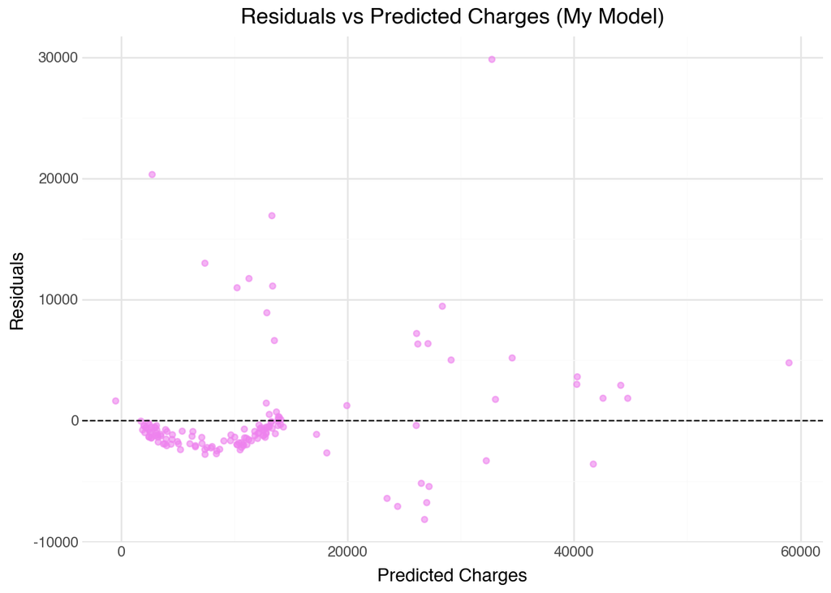

```python
#adding predictions and residuals to test, calculating residuals
test['predicted_charges'] = y_pred_new6 # predictions from My Model
test['residuals'] = test['charges'] - test['predicted_charges']

#residual plot
(
    ggplot(test, aes(x='predicted_charges', y='residuals'))
    + geom_point(alpha=0.6, color='violet')
    + geom_hline(yintercept=0, color='black', linetype='dashed') #adds line at 0 to show shift from positive to negative values easier
    + labs(
        title='Residuals vs Predicted Charges (My Model)',
        x='Predicted Charges',
        y='Residuals'
    )
    + theme_minimal()
)
```